# 607 Final Project - Cause of Death by Firearm vs State Firearm Laws

Jen Abinette

2022-11-20

### Research question

Are there aspects of gun policy that are predictors of firearm mortality rate?

### Cases

All datasets and relevant information can be found in Github Repository - https://github.com/JAbinette/CUNY-607-Final-Project

Cause of Death by Firearm data retrieved from Centers for Disease Control & Prevention website includes 458 observations grouped by State, Year and Cause of Death Category (ICD Sub-Chapter) including firearm deaths excluding Terrorism, Legal Intervention and Operations of War See Github File: ‘0 - wonder.cdc.gov Underlying Cause of Death cdc - Grp by State, ICD Sub-Chapter.txt’

### CDC 2020 Summary of Death by Firearm

```r
library(tidyr)
library(readxl)
library(dplyr)
# Load CDC Cause of Death by Firearm text file from Github
txt.url = 'https://raw.githubusercontent.com/JAbinette/CUNY-607-Final-Project/main/0%20-%20wonder.cdc.gov%20Underlying%20Cause%20of%20Death%20cdc%20-%20Grp%20by%20State%2C%20ICD%20Sub-Chapter.txt'
cod.ld <- read.delim (txt.url, header=TRUE, sep = "\t")

cod.st_yr <- subset (cod.ld, Year.Code == 2020, select = c("State", "Year.Code", "Deaths", "Population")) %>%
  group_by(State, Year.Code) %>%
  mutate(Firearm_Deaths = sum(Deaths)) %>%
  mutate (Prop.of.Pop = (Firearm_Deaths/Population) ) %>%
  ungroup()
cod.st_yr <- subset (cod.st_yr, State != "District of Columbia", select =c("State", "Year.Code", "Firearm_Deaths", "Prop.of.Pop")) %>%
  distinct() %>%
  na.omit()
```

### CDC Reported Deaths by State in 2020

```r
# Load CDC Deaths by State in 2020 text file from Github
txt.url = 'https://raw.githubusercontent.com/JAbinette/CUNY-607-Final-Project/main/0%20-%20wonder.cdc.gov%202020%20Deaths%20by%20State.txt'
cod.all <- read.delim (txt.url, header=TRUE, sep = "\t")
cod.all <- subset(cod.all, Year.Code == 2020 & State != "District of Columbia", select = c("State", "Deaths"))

# Merge with Firearm Deaths data
COD <- merge( cod.st_yr, cod.all, by.x = "State", by.y = "State", all.x = TRUE)  %>%
  mutate (Prop.of.Deaths = (Firearm_Deaths/Deaths) )
```

### State Firearm Laws (filtered to only include 2020)

```r
# Download State Firearm Laws spreadsheet and save to your file directory (data saved in Github at https://github.com/JAbinette/CUNY-607-Final-Project/blob/main/0%20-%20statefirearmlaws.org%20Firearm%20Laws%20-%20DATABASE_0.xlsx)
# Set path to excel spreadsheet
path = "0 - statefirearmlaws.org Firearm Laws - DATABASE_0.xlsx"
laws_ld <- read_excel(path)
# Subset data to only include years 2018-2020
laws_ld <- subset (laws_ld, year == 2020)
# Transform from wide to long (excluding last column which is the total number of laws)
laws_ld2 <- pivot_longer ( laws_ld, cols = 3:136, names_to ="Variable", values_to = "Indicator" )
# Remove variable records where the law was not present for that year and State
laws_ld3 <- subset ( laws_ld2, Indicator == 1 )
head(laws_ld3)
```

```
## # A tibble: 6 × 5
##   state    year lawtotal Variable        Indicator
##   <chr>   <dbl>    <dbl> <chr>               <dbl>
## 1 Alabama  2020       10 invcommitment           1
## 2 Alabama  2020       10 danger                  1
## 3 Alabama  2020       10 alcoholism              1
## 4 Alabama  2020       10 dealerh                 1
## 5 Alabama  2020       10 permitconcealed         1
## 6 Alabama  2020       10 ccbackground            1
```

### Add Variable Categories to Merge with State Firearm

```r
# Load Variable Category data for State Firearm Laws data
laws.cat_ld <- read.csv('https://raw.githubusercontent.com/JAbinette/CUNY-607-Final-Project/main/0%20-%20statefirearmlaws.org%20Variable%20Categories%20-%20codebook_0.csv')
# Replace spaces in Category with a period
laws.cat_ld$Category <- make.names (laws.cat_ld$Category)
# Merge
laws_ld4 <- merge( laws_ld3, laws.cat_ld, by.x = "Variable", by.y = "Variable.Name", all.x = TRUE)
laws_ld4 <- subset ( laws_ld4, select = c("state","year","lawtotal","Category"))

library(dplyr)
# Add count of laws by Category
laws_ld4 <- laws_ld4 %>%
  group_by(state, year, lawtotal, Category) %>%
  summarise(Category_count=n(),
            .groups = 'drop')
head(laws_ld4)
```

```
## # A tibble: 6 × 5
##   state    year lawtotal Category                                  Category_co…¹
##   <chr>   <dbl>    <dbl> <chr>                                             <int>
## 1 Alabama  2020       10 Concealed.carry.permitting                            4
## 2 Alabama  2020       10 Dealer.regulations                                    1
## 3 Alabama  2020       10 Domestic.violence                                     2
## 4 Alabama  2020       10 Prohibitions.for.high.risk.gun.possession             3
## 5 Alaska   2020        3 Buyer.regulations                                     1
## 6 Alaska   2020        3 Possession.regulations                                1
## # … with abbreviated variable name ¹Category_count
```

```r
# Transform long to wide
laws <- pivot_wider( laws_ld4, names_from = "Category", values_from = "Category_count")
# Convert NA to zero
laws[is.na(laws)] <- 0

# Merge State Laws data with Cause of Death by State and Year
df <- merge (COD, laws, by.x = c("State"), by.y = c("state"), all.x = TRUE)
df <- subset(df, select = c("State", "Prop.of.Pop", "Prop.of.Deaths", "lawtotal"))
```

# Statistical Analyses

```r
summary(df)
```

```
##     State            Prop.of.Pop        Prop.of.Deaths       lawtotal
##  Length:50          Min.   :0.0000334   Min.   :0.00387   Min.   :  1.00
##  Class :character   1st Qu.:0.0001093   1st Qu.:0.01078   1st Qu.:  9.25
##  Mode  :character   Median :0.0001390   Median :0.01360   Median : 20.50
##                     Mean   :0.0001473   Mean   :0.01390   Mean   : 29.44
##                     3rd Qu.:0.0001920   3rd Qu.:0.01736   3rd Qu.: 40.50
##                     Max.   :0.0002744   Max.   :0.03095   Max.   :111.00
```

### Can the Total Number of Laws predict proportion of Firearm deaths per State Population?

```r
df %>%
  summarise( cor( lawtotal, Prop.of.Pop, use = "complete.obs"))
```

```
##   cor(lawtotal, Prop.of.Pop, use = "complete.obs")
## 1                                       -0.7024303
```

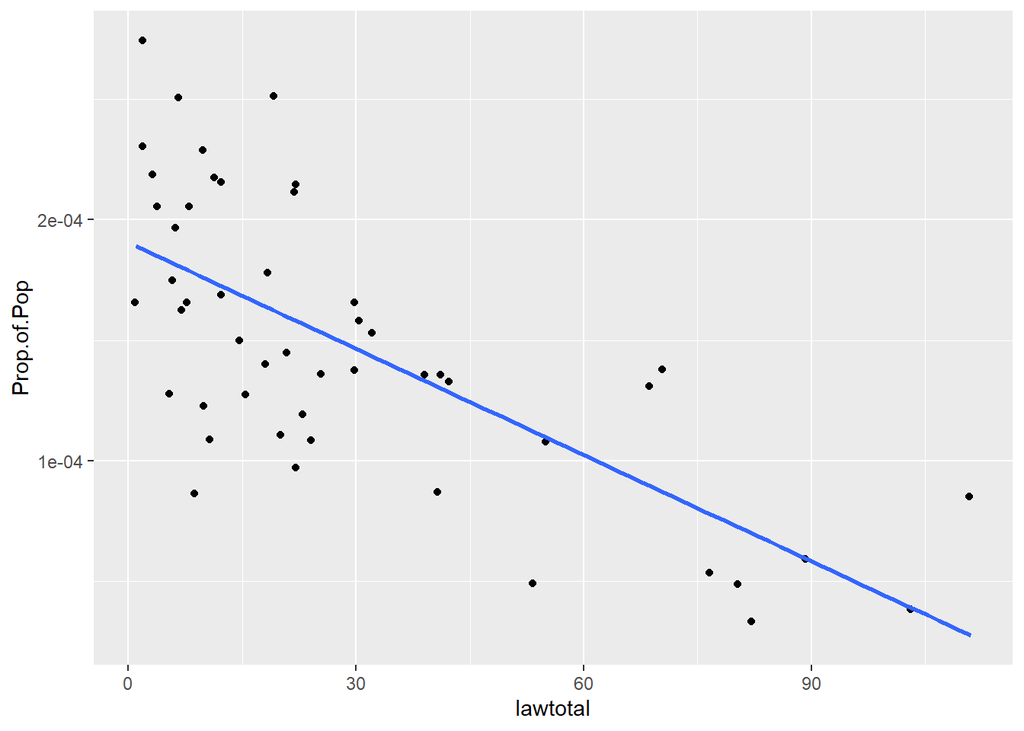

```r
library(ggplot2)
ggplot(data = df, aes(x = lawtotal, y = Prop.of.Pop)) + geom_jitter() + stat_smooth(method = "lm", se = FALSE)
```

```r
# Simple Linear Regression
m.pop <- lm(Prop.of.Pop ~ lawtotal, data = df)
summary(m.pop)
```

```
##
## Call:
## lm(formula = Prop.of.Pop ~ lawtotal, data = df)
##
## Residuals:
##        Min         1Q     Median         3Q        Max
## -9.100e-05 -2.413e-05 -1.467e-06  3.114e-05  8.876e-05
##
## Coefficients:
##               Estimate Std. Error t value Pr(>|t|)
## (Intercept)  1.906e-04  8.727e-06  21.840  < 2e-16 ***
## lawtotal    -1.470e-06  2.149e-07  -6.837 1.31e-08 ***
## ---
## Signif. codes:  0 '***' 0.001 '**' 0.01 '*' 0.05 '.' 0.1 ' ' 1
##
## Residual standard error: 4.249e-05 on 48 degrees of freedom
## Multiple R-squared:  0.4934, Adjusted R-squared:  0.4829
## F-statistic: 46.75 on 1 and 48 DF,  p-value: 1.305e-08
```

### Check Model Assumptions for Simple Regression

### Linearity and Constant Variability - Conditions both met as there is no apparent pattern in the residuals plot indicating there is linearity and the points are scattered around zero showing constant variability.

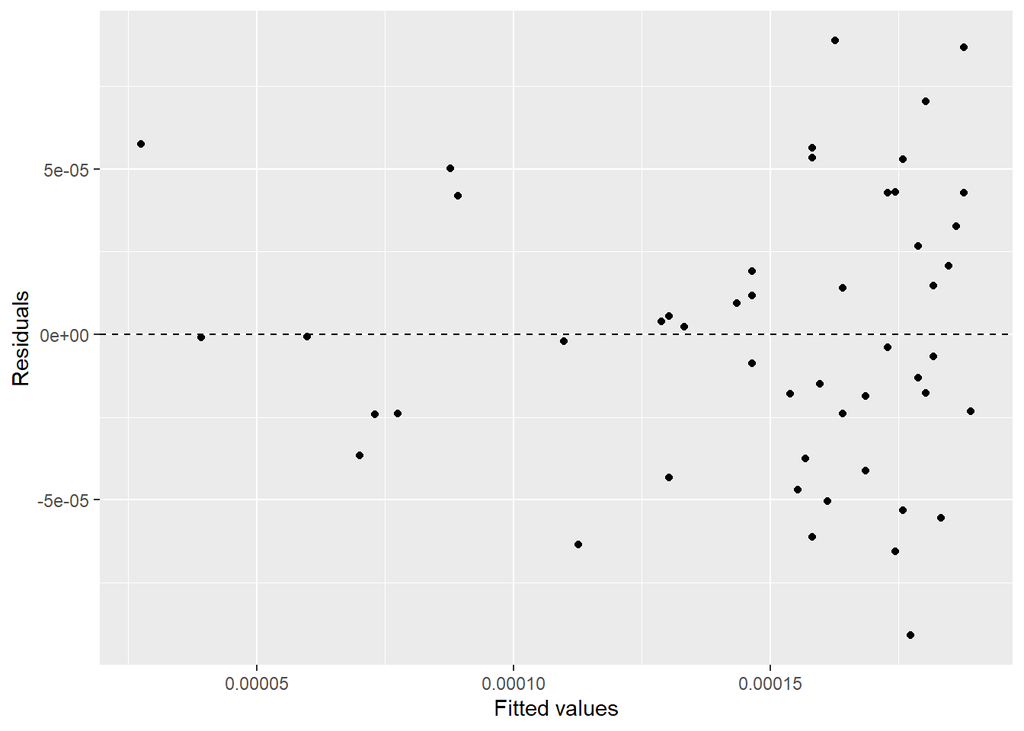

```r
ggplot(data = m.pop, aes(x = .fitted, y = .resid)) +
geom_point() +
geom_hline(yintercept = 0, linetype = "dashed") +
xlab("Fitted values") +
ylab("Residuals")
```

### Nearly Normal Residuals - Condition is met based on below histogram and the normal probability plots.

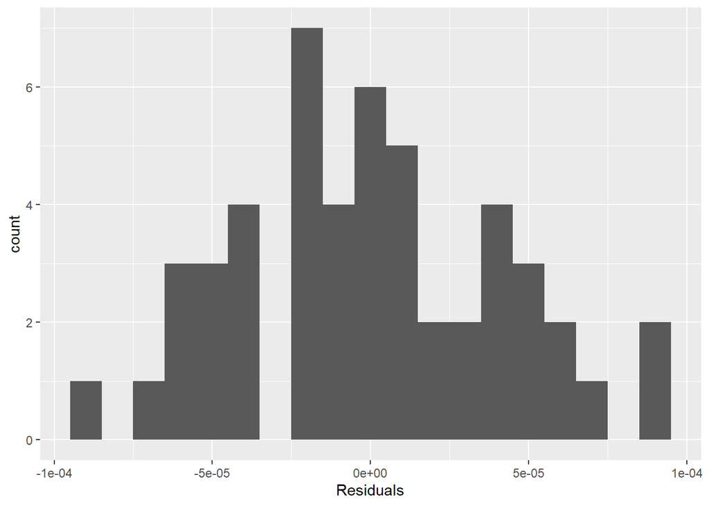

```r
ggplot(data = m.pop, aes(x = .resid)) +
geom_histogram(binwidth = .00001) +
xlab("Residuals")
```

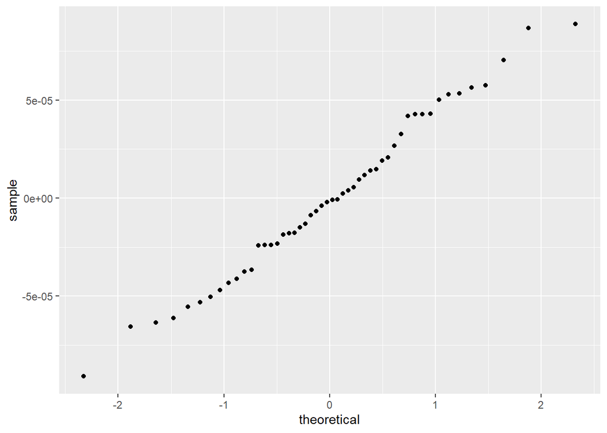

```r
ggplot(data = m.pop, aes(sample = .resid)) + stat_qq()
```

### Can the Number and Category of Firearm Laws predict proportion of Firearm deaths per State Population?

```r
# Merge State Laws data with Cause of Death by State and Year
df2 <- merge (COD, laws, by.x = c("State"), by.y = c("state"), all.x = TRUE)

# Multiple Linear Regression
m_2020 <- lm(Prop.of.Pop ~ Concealed.carry.permitting + Dealer.regulations + Domestic.violence +
Prohibitions.for.high.risk.gun.possession + Buyer.regulations + Possession.regulations + Stand.your.ground + Ammunition.regulations + Assault.weapons.and.large.capacity.magazines +
Background.checks + Child.access.prevention + Gun.trafficking + Immunity + Preemption, data = df2)
summary(m_2020)
```

```
##
## Call:
## lm(formula = Prop.of.Pop ~ Concealed.carry.permitting + Dealer.regulations +
##     Domestic.violence + Prohibitions.for.high.risk.gun.possession +
##     Buyer.regulations + Possession.regulations + Stand.your.ground +
##     Ammunition.regulations + Assault.weapons.and.large.capacity.magazines +
##     Background.checks + Child.access.prevention + Gun.trafficking +
##     Immunity + Preemption, data = df2)
##
## Residuals:
##        Min         1Q     Median         3Q        Max
## -6.912e-05 -1.866e-05 -4.747e-06  2.022e-05  9.049e-05
##
## Coefficients:
##                                                Estimate Std. Error t value
## (Intercept)                                   1.749e-04  1.387e-05  12.612
## Concealed.carry.permitting                    1.298e-06  3.768e-06   0.344
## Dealer.regulations                           -5.773e-07  3.243e-06  -0.178
## Domestic.violence                            -1.357e-06  2.295e-06  -0.591
## Prohibitions.for.high.risk.gun.possession     1.717e-06  3.894e-06   0.441
## Buyer.regulations                            -4.398e-06  3.330e-06  -1.321
## Possession.regulations                        7.210e-06  4.265e-06   1.690
## Stand.your.ground                            -3.039e-05  2.141e-05  -1.420
## Ammunition.regulations                        1.221e-05  1.024e-05   1.192
## Assault.weapons.and.large.capacity.magazines  3.794e-06  5.031e-06   0.754
## Background.checks                            -7.961e-07  2.845e-06  -0.280
## Child.access.prevention                      -8.916e-06  3.997e-06  -2.231
## Gun.trafficking                              -8.205e-06  7.430e-06  -1.104
## Immunity                                     -1.213e-06  2.057e-05  -0.059
## Preemption                                   -2.533e-05  1.217e-05  -2.082
##                                              Pr(>|t|)
## (Intercept)                                  1.41e-14 ***
## Concealed.carry.permitting                     0.7326
## Dealer.regulations                             0.8597
## Domestic.violence                              0.5582
## Prohibitions.for.high.risk.gun.possession      0.6620
## Buyer.regulations                              0.1951
## Possession.regulations                         0.0998 .
## Stand.your.ground                              0.1645
## Ammunition.regulations                         0.2414
## Assault.weapons.and.large.capacity.magazines   0.4558
## Background.checks                              0.7813
## Child.access.prevention                        0.0322 *
## Gun.trafficking                                0.2770
## Immunity                                       0.9533
## Preemption                                     0.0447 *
## ---
## Signif. codes:  0 '***' 0.001 '**' 0.01 '*' 0.05 '.' 0.1 ' ' 1
##
## Residual standard error: 4.141e-05 on 35 degrees of freedom
## Multiple R-squared:  0.6493, Adjusted R-squared:  0.509
## F-statistic: 4.628 on 14 and 35 DF,  p-value: 0.0001146
```

### Fit the Best Model using backward-selection and p-value as the selection criterion

```r
# Variables removed highest p-value at a time: Immunity, Dealer.regulations, Concealed.carry.permitting, Background.checks, Prohibitions.for.high.risk.gun.possession, Domestic.violence, Assault.weapons.and.large.capacity.magazines, Gun.trafficking,  Ammunition.regulations, Buyer.regulations, Possession.regulations
m_bestfit <- lm(Prop.of.Pop ~ Stand.your.ground + Child.access.prevention + Preemption, data = df2)
summary(m_bestfit)
```

```
##
## Call:
## lm(formula = Prop.of.Pop ~ Stand.your.ground + Child.access.prevention +
##     Preemption, data = df2)
##
## Residuals:
##        Min         1Q     Median         3Q        Max
## -7.730e-05 -2.465e-05 -7.675e-06  2.893e-05  9.012e-05
##
## Coefficients:
##                           Estimate Std. Error t value Pr(>|t|)
## (Intercept)              1.842e-04  7.847e-06  23.480  < 2e-16 ***
## Stand.your.ground       -3.813e-05  1.314e-05  -2.902  0.00567 **
## Child.access.prevention -6.860e-06  2.492e-06  -2.753  0.00843 **
## Preemption              -1.777e-05  7.425e-06  -2.393  0.02083 *
## ---
## Signif. codes:  0 '***' 0.001 '**' 0.01 '*' 0.05 '.' 0.1 ' ' 1
##
## Residual standard error: 3.982e-05 on 46 degrees of freedom
## Multiple R-squared:  0.5737, Adjusted R-squared:  0.5459
## F-statistic: 20.64 on 3 and 46 DF,  p-value: 1.284e-08
```

### Check Model Assumptions

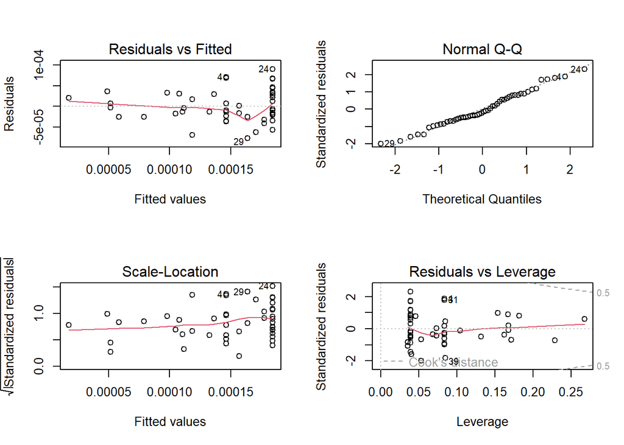

```r
par(mfrow = c(2, 2))
plot(m_bestfit)
```

### Conclusions

The total number of firearm laws is a significant predictor and accounts for 49% of the variability in Firearm Deaths as a Proportion of the State Population. In breaking down the firearm laws by category, a multiple regression analysis determined that the number of Stand Your Ground, Child Access Prevention, and Preemption firearm laws can explain 55% of the variability.